# COVID-19 Report

2025-06-14

### Question of interest

How did COVID-19 case and death counts evolve over time in the U.S. and globally?

### Description of the data

This project uses publicly available COVID-19 time-series data from the Johns Hopkins University GitHub repository. It includes daily cumulative counts of confirmed cases and deaths for U.S. states and global regions. The data was cleaned and reshaped for analysis, merged with population figures, and used to calculate per-capita metrics. While comprehensive, the dataset may have reporting inconsistencies and lacks deeper social or economic context.

### Import Libraries

```r
# load in tidyverse in order to be able to perform the following analysis

if (!require(tidyverse)) install.packages("tidyverse")
library(tidyverse)
```

### Read in Data

```r
# Save url of interest as variable

url_in <- "https://raw.githubusercontent.com/CSSEGISandData/COVID-19/refs/heads/master/csse_covid_19_data/csse_covid_19_time_series/"

# Save each file of interest as a string

file_names <- c("time_series_covid19_confirmed_US.csv",
                "time_series_covid19_confirmed_global.csv",
                "time_series_covid19_deaths_US.csv",
                "time_series_covid19_deaths_global.csv")

# Combine url with each file to get full url of interest

urls <- str_c(url_in, file_names)

# Read in raw Github data

us_cases <- read_csv(urls[1])
global_cases <- read_csv(urls[2])
us_deaths <- read_csv(urls[3])
global_deaths <- read_csv(urls[4])
```

### Data Cleaning and Wrangling

```r
# Pivot global cases to long format
global_cases <- global_cases %>%
  pivot_longer(cols = -c(`Province/State`, `Country/Region`, Lat, Long),
               names_to = "date",
               values_to = "cases") %>%
  select(-Lat, -Long)

# Pivot global deaths to long format
global_deaths <- global_deaths %>%
  pivot_longer(cols = -c(`Province/State`, `Country/Region`, Lat, Long),
               names_to = "date",
               values_to = "deaths") %>%
  select(-Lat, -Long)

# Merge global cases and deaths
global <- global_cases %>%
  full_join(global_deaths, by = c("Province/State", "Country/Region", "date")) %>%
  rename(Province_State = `Province/State`,
         Country_Region = `Country/Region`) %>%
  mutate(date = mdy(date))

# Add unique region key
global <- global %>%
  unite("Combined_Key", c(Province_State, Country_Region),
        sep = ", ", na.rm = TRUE, remove = FALSE)

# Import UID and population lookup data
uid_url <- "https://raw.githubusercontent.com/CSSEGISandData/COVID-19/master/csse_covid_19_data/UID_ISO_FIPS_LookUp_Table.csv"

uid <- read_csv(uid_url) %>%
  select(-Lat, -Long_, -Combined_Key, -code3, -iso2, -iso3, -Admin2)

# Merge UID data for population
global <- global %>%
  left_join(uid, by = c("Province_State", "Country_Region")) %>%
  select(Province_State, Country_Region, date, cases, deaths, Population, Combined_Key)
```

### Visualization 1

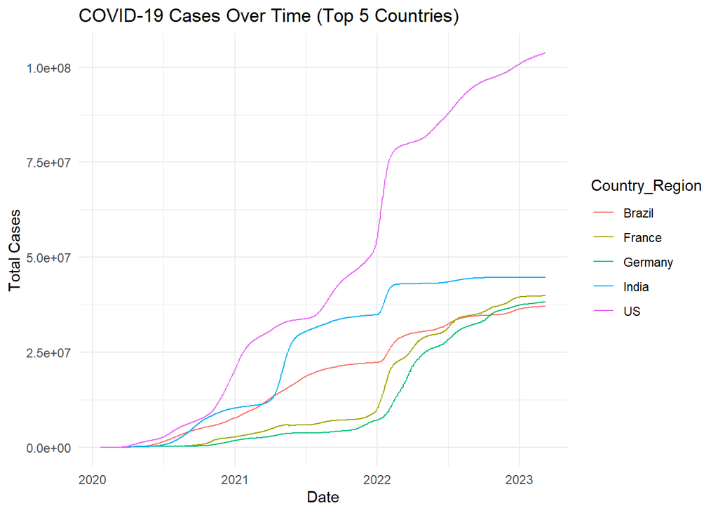

```r
top5_countries <- global %>%
  group_by(Country_Region) %>%
  summarize(total_cases = max(cases, na.rm = TRUE)) %>%
  top_n(5, total_cases) %>%
  pull(Country_Region)

global %>%
  filter(Country_Region %in% top5_countries) %>%
  group_by(Country_Region, date) %>%
  summarize(cases = sum(cases), .groups = "drop") %>%
  ggplot(aes(x = date, y = cases, color = Country_Region)) +
  geom_line() +
  labs(title = "COVID-19 Cases Over Time (Top 5 Countries)",
       y = "Total Cases", x = "Date") +
  theme_minimal()
```

### Visualization 2

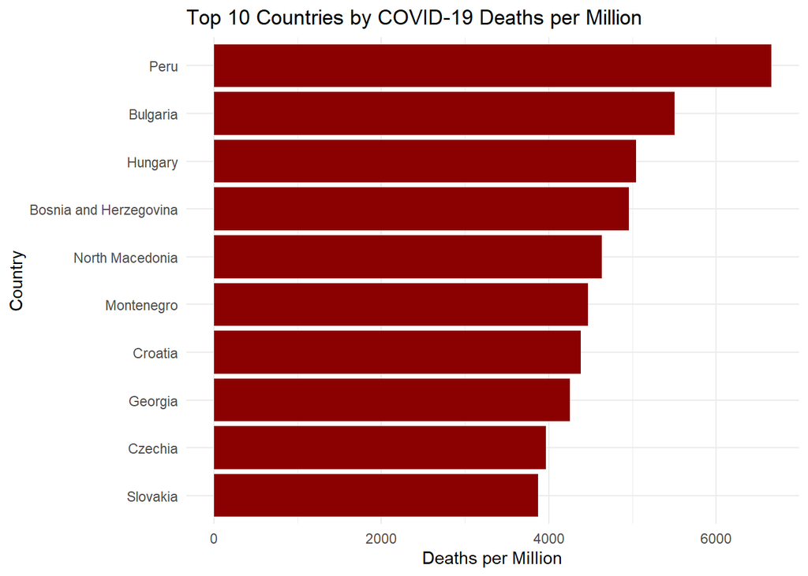

```r
latest_date <- max(global$date, na.rm = TRUE)

global %>%
  filter(date == latest_date, !is.na(Population), Population > 0) %>%
  group_by(Country_Region) %>%
  summarize(deaths = sum(deaths),
            pop = sum(Population),
            deaths_per_mil = deaths * 1e6 / pop,
            .groups = "drop") %>%
  top_n(10, deaths_per_mil) %>%
  ggplot(aes(x = reorder(Country_Region, deaths_per_mil), y = deaths_per_mil)) +
  geom_col(fill = "darkred") +
  coord_flip() +
  labs(title = "Top 10 Countries by COVID-19 Deaths per Million",
       x = "Country", y = "Deaths per Million") +
  theme_minimal()
```

### Visualization 3

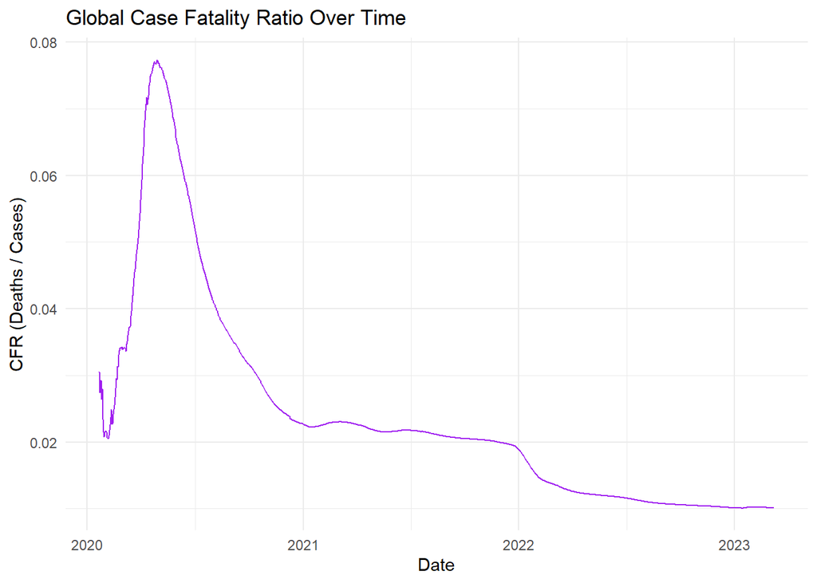

```r
global %>%
  filter(cases > 0) %>%
  group_by(date) %>%
  summarize(total_cases = sum(cases),
            total_deaths = sum(deaths),
            cfr = total_deaths / total_cases,
            .groups = "drop") %>%
  ggplot(aes(x = date, y = cfr)) +
  geom_line(color = "purple") +
  labs(title = "Global Case Fatality Ratio Over Time",
       x = "Date", y = "CFR (Deaths / Cases)") +
  theme_minimal()
```

### Modeling Data

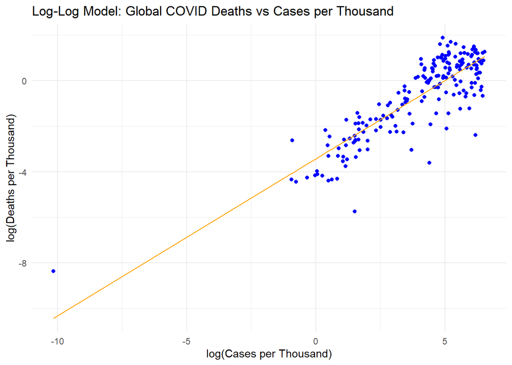

```r
global_model_data <- global %>%
  filter(!is.na(Population), Population > 0, cases > 0, deaths > 0) %>%
  group_by(Country_Region) %>%
  summarize(cases = max(cases),
            deaths = max(deaths),
            pop = max(Population),
            .groups = "drop") %>%
  mutate(cases_per_thou = 1000 * cases / pop,
         deaths_per_thou = 1000 * deaths / pop,
         log_cases = log(cases_per_thou),
         log_deaths = log(deaths_per_thou)) %>%
  filter(is.finite(log_cases), is.finite(log_deaths))

log_mod <- lm(log_deaths ~ log_cases, data = global_model_data)

global_model_data <- global_model_data %>%
  mutate(pred = predict(log_mod))

ggplot(global_model_data, aes(x = log_cases, y = log_deaths)) +
  geom_point(color = "blue") +
  geom_line(aes(y = pred), color = "orange") +
  labs(title = "Log-Log Model: Global COVID Deaths vs Cases per Thousand",
       x = "log(Cases per Thousand)", y = "log(Deaths per Thousand)") +
  theme_minimal()
```

### Conclusion

This analysis explored global COVID-19 trends using Johns Hopkins time-series data. We visualized patterns in cases, deaths, and fatality rates, highlighting significant variation across countries. A log-log regression showed a positive relationship between case and death rates, though influenced by reporting and demographic factors. While insightful, the analysis is limited by data inconsistencies and lack of contextual variables. Future work could benefit from incorporating healthcare and policy data for deeper insights.

### Bias Identification

- Variable Selection Bias: The choice of which variables to include in the analysis can introduce bias by framing the story in a limited way. Key social, economic, or contextual factors may be left out—not because they are unimportant, but because they are not as readily available or measurable. This can lead to incomplete or skewed interpretations of complex issues like public health or law enforcement outcomes.
- Reporting and Testing Bias: COVID-19 case and death counts rely heavily on national and local testing capabilities and reporting standards, which vary significantly across states and countries. This may lead to underreporting or inconsistencies in the data.
- Aggregated Data Limitations: The use of aggregated, time-series data limits the ability to account for local-level nuances, such as hospital access, public health policies, or demographic differences, which can impact case and fatality rates.